# model_comparison

Xinyu Zhang

6/24/2020

loading data, and fitting a regression line on the scatterplot, treating ratings by different SLPs as separate entries

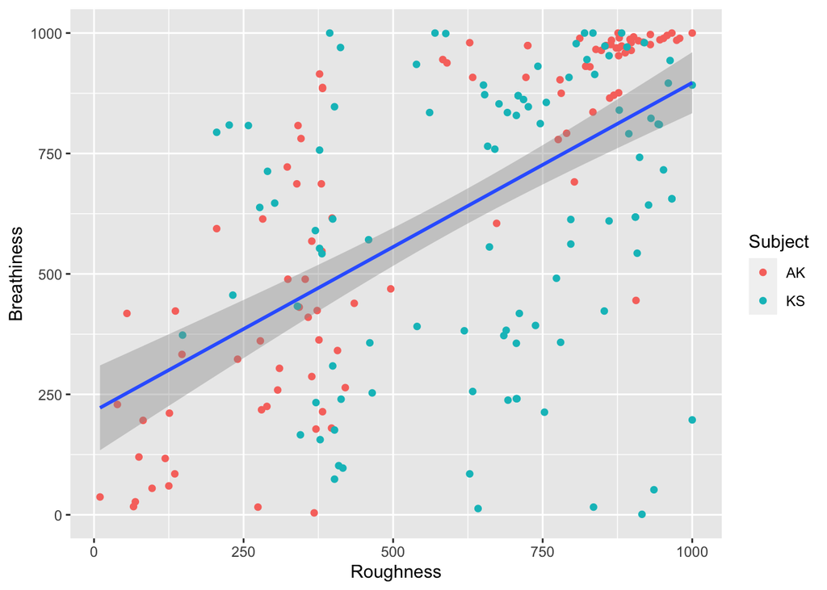

```r
merged <- read.csv("merged.csv")
#scatter plot
library(ggplot2)
ggplot(data = merged, aes(x = Roughness, y = Breathiness)) +
  geom_point(aes(color = Subject)) +
  geom_smooth(method = "lm")
```

Comparing the above with averaged roughness and breathiness scores:

```r
library(dplyr)
```

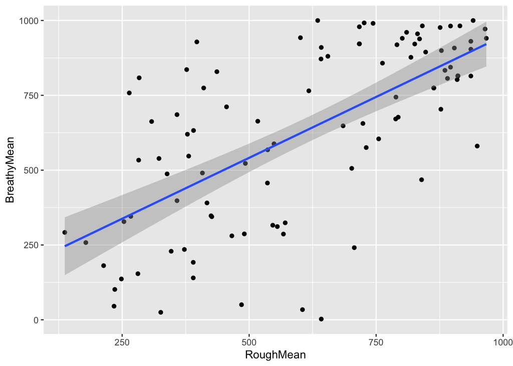

```r
#plotting and fitting regression line
av_AVQI_B <- read.csv("av_AVQI_B.csv")
av_AVQI_R <- read.csv("av_AVQI_R.csv")
av_AVQI_BR <-left_join(av_AVQI_B,av_AVQI_R, by = "dummy")
ggplot(data = av_AVQI_BR, aes(x = RoughMean, y = BreathyMean)) +
  geom_point() +
  geom_smooth(method = "lm")
```

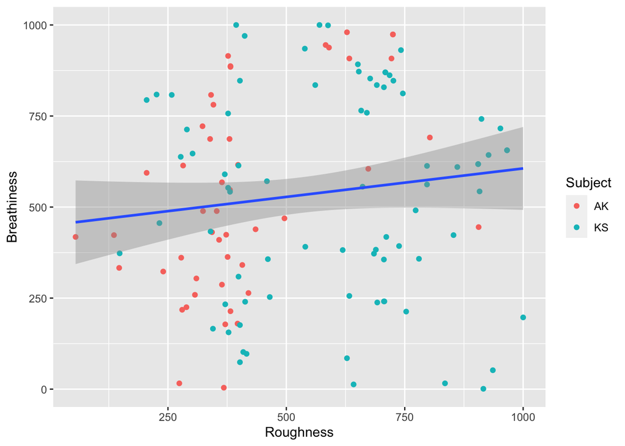

```r
#excluding the upper-right-most and lower-left-most squares, unaveraged
merged <- read.csv("merged.csv")
merged2 <- merged %>%
  filter(!(Roughness > 750 & Breathiness > 750) & !(Roughness < 250 & Breathiness <250))

#new scatter plot
ggplot(data = merged2, aes(x = Roughness, y = Breathiness)) +
         geom_point(aes(color = Subject)) +
         geom_smooth(method = "lm")
```

^not much correlation between Roughness and Breathiness here anymore.

To reshape the tables and select the needed data points (excluding the two extreme corners):

```r
library(dplyr)
#reading in listening test results
listener1 <- read.csv("Results_AK.csv", header = TRUE, sep = ";")
listener2 <- read.csv("Results_KS.csv", header = TRUE, sep = ";")
#renaming the two answers, removing column "Num"
SLP1 <- listener1 %>%
  rename(Roughness = Answer1, Breathiness = Answer2)%>%
  dplyr::select(-Num)

SLP2 <- listener2 %>%
  rename(Roughness = Answer1, Breathiness = Answer2)%>%
  dplyr::select(-Num)

#join the two listening results tables by matching both Speaker and T
SLP <-rbind(SLP1,SLP2) %>%
  dplyr::select(-Z, -A) %>% #filterting out the extreme corners
  filter(!(Roughness > 750 & Breathiness > 750) & !(Roughness < 250 & Breathiness <250))

SLP$dummy <- paste(SLP$Speaker, "-", SLP$T)

glimpse(SLP)
```

```
## Rows: 123
## Columns: 6
## $ Roughness   <int> 368, 136, 633, 282, 55, 382, 307, 398, 380, 280, 278, 310…
## $ Breathiness <int> 4, 423, 908, 614, 418, 885, 259, 616, 687, 218, 361, 304,…
## $ Speaker     <fct> S34, S9, S10, S46, S1, S29, S38, S44, S25, S5, S10, S43, …
## $ T           <fct> Pre, Pre, P6mnd, P6mnd, Pre, Pre, P6mnd, Pre, Pre, Pre, P…
## $ Subject     <fct> AK, AK, AK, AK, AK, AK, AK, AK, AK, AK, AK, AK, AK, AK, A…
## $ dummy       <chr> "S34 - Pre", "S9 - Pre", "S10 - P6mnd", "S46 - P6mnd", "S…
```

Merging the two subjective scores with the AVQI table:

```r
library(dplyr)
AVQI <- read.csv("AVQI_results_new.csv")
#create a dummy column as an identifier for each "Speaker-T" entry
AVQI$dummy <- paste(AVQI$Speaker, "-", AVQI$T)

SLP_RB <- SLP %>%
  dplyr::select(Roughness, Breathiness, dummy) #no need to select T and Speaker since they are combined as the identifier column "dummy", and not need to select "Subject" if we want to treat them as separate entries

#merging ("left-join" only appends AVQI entries that has SLP rating correspondents)
library(dplyr)
AVQI_R <-left_join(SLP_RB,AVQI, by = "dummy")%>%
  dplyr::select(-Breathiness, -Speaker, -T, -AVQI, -Version, -dummy) #AVQI version is not relavant here

AVQI_B <-left_join(SLP_RB,AVQI, by = "dummy")%>%
  dplyr::select(-Roughness, -Speaker, -T, -AVQI, -Version, -dummy)

#converting jitter into a numeric variable
AVQI_R$Jitter <- as.numeric(levels(AVQI_R$Jitter))[AVQI_R$Jitter]
AVQI_B$Jitter <- as.numeric(levels(AVQI_B$Jitter))[AVQI_B$Jitter]
#removing rows with NA values
selectedR <- AVQI_R[complete.cases(AVQI_R), ]
selectedB <- AVQI_B[complete.cases(AVQI_B), ]
```

Stepwise model comparison for roughness:

```r
library(tidyverse)
library(caret)
library(leaps)
library(MASS)
min.model <- lm(Roughness ~., data = selectedR, na.action = "na.omit")
step.model<- stepAIC(min.model, direction = "both",
                      trace = FALSE)
summary(step.model)
```

```
##
## Call:
## lm(formula = Roughness ~ HNR, data = selectedR, na.action = "na.omit")
##
## Residuals:
##     Min      1Q  Median      3Q     Max
## -419.02 -174.25  -27.69  145.77  514.11
##
## Coefficients:
##             Estimate Std. Error t value Pr(>|t|)
## (Intercept)  280.652     63.943   4.389 2.48e-05 ***
## HNR           18.061      4.424   4.083 8.09e-05 ***
## ---
## Signif. codes:  0 '***' 0.001 '**' 0.01 '*' 0.05 '.' 0.1 ' ' 1
##
## Residual standard error: 207.6 on 119 degrees of freedom
## Multiple R-squared:  0.1229, Adjusted R-squared:  0.1155
## F-statistic: 16.67 on 1 and 119 DF,  p-value: 8.094e-05
```

The best roughness model has one variable: HNR

Alternative model selection:

```r
models <- regsubsets(Roughness~., data = selectedR, nvmax = 7,
                     method = "seqrep") #7 because 7 variables in total

# Set seed for reproducibility
set.seed(1802)
# Set up repeated k-fold cross-validation
train.control <- trainControl(method = "cv", number = 10)
# Train the model
step.model <- train(Roughness ~., data = selectedR,
                    method = "leapBackward",
                    tuneGrid = data.frame(nvmax = 1:7),
                    trControl = train.control
                    )
step.model$results
```

```
##   nvmax     RMSE  Rsquared      MAE   RMSESD RsquaredSD    MAESD
## 1     1 205.3350 0.1488608 177.6254 28.69617  0.1158328 30.33928
## 2     2 206.7604 0.1465733 178.4845 30.24162  0.1310779 31.85157
## 3     3 208.9587 0.1294977 180.3055 30.20624  0.1268695 31.75262
## 4     4 211.2794 0.1131668 182.3229 32.27152  0.1314250 33.39477
## 5     5 211.6230 0.1134562 182.9824 32.74697  0.1373259 33.60117
## 6     6 211.7848 0.1156816 183.5619 32.85651  0.1423869 33.38071
## 7     7 212.0516 0.1138558 183.5212 32.58638  0.1376237 33.27470
```

```r
#lowest RMSE occurs when there is 1 predictor:
step.model$bestTune
```

```
##   nvmax
## 1     1
```

```r
summary(step.model$finalModel)
```

```
## Subset selection object
## 7 Variables  (and intercept)
##         Forced in Forced out
## CPPS        FALSE      FALSE
## HNR         FALSE      FALSE
## Jitter      FALSE      FALSE
## Shimmer     FALSE      FALSE
## ShdB        FALSE      FALSE
## Slope       FALSE      FALSE
## Tilt        FALSE      FALSE
## 1 subsets of each size up to 1
## Selection Algorithm: backward
##          CPPS HNR Jitter Shimmer ShdB Slope Tilt
## 1  ( 1 ) " "  "*" " "    " "     " "  " "   " "
```

Same result. The best roughness model contains one variable: HNR

Calculating the coefficients in the best model:

```r
#coefficients of the best model
coef(step.model$finalModel, 1)
```

```
## (Intercept)         HNR
##   280.65232    18.06131
```

Stepwise model comparison for Breathiness:

```r
min.model <- lm(Breathiness ~., data = selectedB, na.action = "na.omit")
step.model<- stepAIC(min.model, direction = "both",
                      trace = FALSE)
summary(step.model)
```

```
##
## Call:
## lm(formula = Breathiness ~ CPPS + HNR + Shimmer + ShdB + Slope,
##     data = selectedB, na.action = "na.omit")
##
## Residuals:
##     Min      1Q  Median      3Q     Max
## -448.14 -146.78   -2.95  131.54  616.16
##
## Coefficients:
##             Estimate Std. Error t value Pr(>|t|)
## (Intercept)  -47.859    280.127  -0.171  0.86464
## CPPS          92.076     14.114   6.524 1.92e-09 ***
## HNR          -39.326     12.687  -3.100  0.00244 **
## Shimmer       64.629     31.295   2.065  0.04115 *
## ShdB        -870.942    362.538  -2.402  0.01789 *
## Slope        -13.378      8.666  -1.544  0.12540
## ---
## Signif. codes:  0 '***' 0.001 '**' 0.01 '*' 0.05 '.' 0.1 ' ' 1
##
## Residual standard error: 205.9 on 115 degrees of freedom
## Multiple R-squared:  0.4623, Adjusted R-squared:  0.4389
## F-statistic: 19.77 on 5 and 115 DF,  p-value: 3.519e-14
```

The best breathiness model contains five variables: CPPS, HNR, Shimmer, ShdB, Slope

Model selection with alternative method:

```r
models <- regsubsets(Breathiness~., data = selectedB, nvmax = 7,
                     method = "seqrep") #7 because there are 7 variables in total

# Set seed for reproducibility
set.seed(1803)
# Set up repeated k-fold cross-validation
train.control <- trainControl(method = "cv", number = 10)
# Train the model
step.model <- train(Breathiness ~., data = selectedB,
                    method = "leapBackward",
                    tuneGrid = data.frame(nvmax = 1:7),
                    trControl = train.control
                    )
step.model$results
```

```
##   nvmax     RMSE  Rsquared      MAE   RMSESD RsquaredSD    MAESD
## 1     1 214.0960 0.4444796 177.1000 40.54009  0.2729875 37.83606
## 2     2 207.1189 0.4786098 172.0657 39.39156  0.2406042 38.96477
## 3     3 211.7015 0.4654904 175.7291 41.29997  0.2435201 39.31503
## 4     4 213.6087 0.4754415 177.8503 51.46686  0.2373174 43.51739
## 5     5 209.3599 0.4976111 174.0832 51.26163  0.2355656 43.94983
## 6     6 212.8843 0.4857453 177.3074 50.90490  0.2423516 43.02356
## 7     7 213.2023 0.4835175 177.4702 50.90180  0.2409362 43.09510
```

```r
step.model$bestTune
```

```
##   nvmax
## 2     2
```

```r
summary(step.model$finalModel)
```

```
## Subset selection object
## 7 Variables  (and intercept)
##         Forced in Forced out
## CPPS        FALSE      FALSE
## HNR         FALSE      FALSE
## Jitter      FALSE      FALSE
## Shimmer     FALSE      FALSE
## ShdB        FALSE      FALSE
## Slope       FALSE      FALSE
## Tilt        FALSE      FALSE
## 1 subsets of each size up to 2
## Selection Algorithm: backward
##          CPPS HNR Jitter Shimmer ShdB Slope Tilt
## 1  ( 1 ) "*"  " " " "    " "     " "  " "   " "
## 2  ( 1 ) "*"  "*" " "    " "     " "  " "   " "
```

The RMSE is lowest when there are 2 variables: CPPS and HNR

Calculating the coefficients in the best model:

```r
#coefficients of the best model
coef(step.model$finalModel, 2)
```

```
## (Intercept)        CPPS         HNR
##   -66.40761    85.66396   -20.75355
```

Running the principal component analysis:

```r
#remember to remove roughness here
pca_rough <- prcomp(selectedR[2:8], scale = TRUE) #removing the second column i.e. Breathiness and scale the variables (e.g. roughness is on a wider scale than all the rest of the measurements)
pca_rough
```

```
## Standard deviations (1, .., p=7):
## [1] 2.0987556 1.0035323 0.9532981 0.6304862 0.4557366 0.2395958 0.1294438
##
## Rotation (n x k) = (7 x 7):
##                PC1         PC2         PC3         PC4         PC5         PC6
## CPPS     0.4074771  0.17067254  0.34807312 -0.16649001  0.73205346  0.34607251
## HNR      0.4550421 -0.05392648 -0.16967959  0.12305500  0.25797277 -0.82416025
## Jitter  -0.2550689  0.73303707 -0.23795353 -0.54432686  0.05647609 -0.20355967
## Shimmer -0.4504042  0.05183127 -0.07259939  0.38963938  0.38074093 -0.07455289
## ShdB    -0.4532688  0.02265020 -0.09512944  0.33185889  0.40379108 -0.04108711
## Slope   -0.2511724  0.07810194  0.88017828 -0.03709401 -0.12957887 -0.37058110
## Tilt    -0.3007238 -0.64909171 -0.06631728 -0.63049320  0.26373594 -0.12239496
##                  PC7
## CPPS    -0.017058242
## HNR      0.017459390
## Jitter  -0.007536978
## Shimmer -0.697737976
## ShdB     0.714226189
## Slope    0.024529892
## Tilt    -0.042288679
```

PCA does not make sense since we don’t know what categories are the principal components dividing the data into.